Estadística 1 | 2020

[figure not shown]

# Guía de Clase del TP8: Regresión y Correlación Lineal

Docentes: Patricia M. Acetta y Agustin Alesso

# Correlación

## Objetivos

- Obtener el coeficiente de correlación lineal $r$ a traves de datos pareados.
- Determinar si hay evidencia suficiente para respaldar la conclusión de que existe una correlación lineal entre dos variables.

## Definiciones

Existe una correlación entre dos variables cuando los valores de una variable están de alguna manera asociados con los valores de la otra variable. Si al graficar los puntos muestran un patrón que se puede aproximar mediante una línea recta, la correlación es lineal.

## Características

- La muestra de datos pareados (x, y) es una muestra aleatoria simple de datos cuantitativos.
- Los pares de datos (x, y) deben tener una distribución normal bivariada.

-El examen visual del diagrama de dispersión debe confirmar que los puntos se aproximan a un patrón en línea recta.

- No depende de las unidades de las unidades de $Y_1$ e $Y_2$ (adimensional, estandarizado)
- $\rho = (-1, 1)$, el signo indica el sentido de la correlación
- A mayor $|\rho|$, mayor correlación entre $Y_1$ e $Y_2$. Cuando $\rho = 0$, no hay correlación
- Fácil de interpretar y comparable (para muestras de mismo $n$)

## Estimador muestral

$$r = \hat{\rho} = \dfrac{\sum (Y_1 - \bar{Y_1})(Y_2 - \bar{Y_2})}{\sqrt{\sum (Y_1 - \bar{Y_1})^2}\sqrt{\sum (Y_2 - \bar{Y_2})^2}} = \dfrac{s_{Y_1Y_2}}{s_{Y_1}s_{Y_2}}$$

## Prueba de hipótesis

$$H_0: \rho = 0 \\
H_1: \rho \neq 0$$

## Supuestos que deben cumplirse para poder probar hipótesis

1. $Y_1$ e $Y_2$ siguen una distribución normal bivariada $\mathbf{x} \sim N(\mu, \Sigma)$

$$\mu = \left[ \text{E}(Y_1), \text{E}(Y_2) \right]$$

$$\Sigma = \text{Cov}(Y_1,Y_2)$$

2. La varianzas son constantes.
3. Relación lineal entre las variables aleatorias $Y_1$ e $Y_2$.
4. La muestra de pares $(Y_1, Y_2)$ fue extraída al azar.

**Estadístico de prueba**

$$t = \dfrac{r}{\sqrt{\dfrac{1-r^2}{n-2}}} \sim t_{n-2}$$

> Correlación no implica causalidad: No debemos llegar a ninguna conclusión que incluya una declaración sobre una relación de causa-efecto entre las dos variables.

# Regresión

## Objetivos

- Usar datos muestrales pareados para encontrar la ecuación de la línea de regresión.
- Encontrar el mejor valor predicho de una variable dado algún valor de la otra variable.

## Definiciones

Dada una colección de datos muestrales pareados, la línea de regresión (o línea de mejor ajuste, o línea de mínimos cuadrados) es la línea recta que “mejor” se ajusta al diagrama de dispersión de los datos.

Ecuación de regresión:
$$Y_i = \beta_0 + \beta_1 X_i + e_i$$

La ecuación de regresión expresa una relación entre $x$ (llamada variable explicativa, variable predictora, o variable independiente) y $y$ (llamada variable de respuesta o variable dependiente).

## Características

- La muestra de datos pareados (x, y) es una muestra aleatoria de datos cuantitativos. El diagrama de dispersión muestra que los puntos se aproximan a un patrón en línea recta.
- Para cada valor fijo de x, los valores correspondientes de y tienen una distribución normal.
- Para los diferentes valores fijos de x, las distribuciones de los correspondientes valores de y tienen la misma desviación estándar.
- Para los diferentes valores fijos de x, las distribuciones de los valores de y correspondientes tienen medias que se encuentran en la misma línea recta.

## Estimación de parámetros

Procedimiento de mínimos cuadrados: obtención de los valores de $b_0$ y $b_1$ que minimizan la diferencia cuadrática entre elos valores observados y los estimdados por el modelo con $b_0$ y $b_1$ como estimadores.

*Una línea recta satisface la propiedad de mínimos cuadrados si la suma de los cuadrados de los residuos es la suma más pequeña posible.*

**Ordenada al origen:**

$$b_0 = \dfrac{\sum Y}{n} - b_1 \dfrac{\sum X}{n} = \bar{Y} - b_1\bar{X}$$

*Interpretación:*

La ordenada al origen o $b_0$, es el punto donde la recta de regresión lineal, intercepta el eje $y$, es decir el valor de $y$ cuando $x$ = 0. Por lo tanto si en el rango de datos muestreados o analizados no se estudió ese valor de $x$ = 0, no se puede inferir ni interpretar la ordenada al origen.

**Pendiente:**

$$b_1 = \dfrac{\sum(X- \bar{X})(Y - \bar{Y})}{\sum (X- \bar{X})^2}$$

*Interpretación:*

Al trabajar con dos variables relacionadas por una ecuación de regresión, el **cambio marginal** de una variable es la cantidad que cambia cuando la otra se modifica en exactamente una unidad. La pendiente $b_1$ en la ecuación de regresión representa el cambio marginal en $y$ que ocurre cuando $x$ cambia en una unidad.

## Inferencia sobre los parámetros

### $\beta_1$

**Intervalo de confianza**
$$\text{IC}_{1-\alpha}= b_1 \pm t_{n-2; 1-\alpha/2} s_{b_1}$$

**Prueba de hipótesis**
$$H_0: \beta_1 = 0 \quad vs \quad H_1: \beta_1 \neq 0$$

$$t = \dfrac{b_1 - 0}{s_{b_1}} \sim t_{n-2} \quad s_{b_1} = s_e \sqrt{\dfrac{1}{\sum (X_i - \bar{X})^2}}$$

### $\beta_0$

**Intervalo de confianza**
$$\text{IC}_{1-\alpha} = b_0 \pm t_{n-2; 1-\alpha/2} s_{b_0}$$

**Prueba de hipótesis**
$$H_0: \beta_0 = 0 \quad vs \quad H_1: \beta_0 \neq 0$$

$$t = \dfrac{b_0 - 0}{s_{b_0}} \sim t_{n-2} \quad s_{b_0} = s_e\sqrt{\dfrac{1}{n} + \dfrac{\bar{X}^2}{\sum (X_i - \bar{X})^2}}$$

## Supuestos

1. $X$ es una **variable fija**, i.e. medida sin error y bajo control del investigador (*Modelo 1*)
2. $Y$ es una **variable aleatoria** y para cualquier $X_i$ el valor esperado es la **función lineal** $f(X) = \beta_0 + \beta_1X$
   $$\text{E}(Y_i) = \mu_Y = \beta_0 + \beta_1 X_i$$
   o bien, los **errores tienen esperanza igual a 0**
   $$\text{E}(e_i) = 0$$
3. Los errores $e_i$ son **independientes**, i.e.
   $$\text{Cov}(e_i, e_j) = 0$$
4. Errores tienen **distribución normal con media 0 y varianza constante**
   $$e_i \sim N(0, \sigma^2_e) \\$$

Los supuestos son necesarios para obtener estimadores insesgados y pruebas de hipótesis válidas.

## Error estándar residual

**$\sigma_e$**

Los residuos ($e_i$) son las diferencias entre los valores observados ($Y_i$) y los estimados por la recta de regresión ($\hat{Y}_i$)

$$e_i = Y_i - \hat{Y_i} = [Y_i - (b_0 + b_1X_i)]$$

La varianza $\sigma^2_e$ indica la variabilidad de la distribucion condicional de $Y|X$ y se estima a partir de la varianza muestral de los $e_i$:

$$s^2_e = \dfrac{\sum (e_i - \bar{e})^2}{n-2} = \dfrac{\sum e^2_i}{n-2} \\
s_e = \sqrt{s^2_e}$$

Esta medida es un indicador de la calidad del modelo: **cuanto más bajo, mejor.**

## Intervalos

Un **intervalo de confianza de la recta de regresión** es un rango de valores utilizados para estimar la respuesta promedio esperada para un determinado valor de $x_0$.

Un **intervalo de predicción** o **intervalo de confianza de la predicción** es un rango de valores utilizados para estimar una variable (como un valor predicho de $y$ en una ecuación de regresión), $\bar{y}|x_0$.

## Coeficiente de determinación

El valor de $R^2$ es la proporción de la variación en $y$ que se explica por la relación lineal entre $x$ e $y$.

El coeficiente de determinación es la proporción de la variación en $y$ que se explica por la línea de regresión. También se lo denomina **bondad de ajuste**.

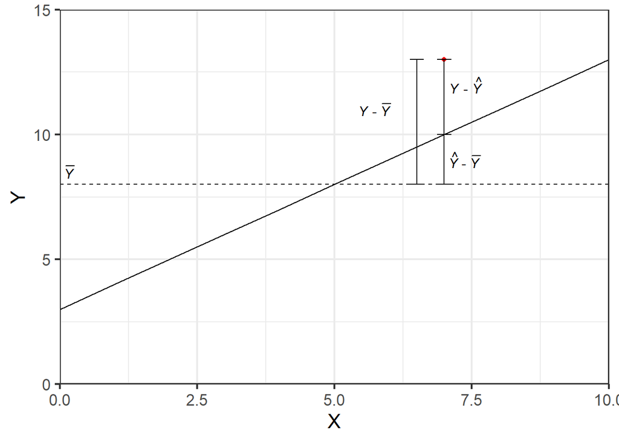

En la gráfica:

$$\begin{array}{a}
& \sum \left(Y_i - \bar{Y} \right)^2 & = & \sum \left(\hat{Y}_i - \bar{Y} \right)^2 & + & \sum \left(Y_i - \hat{Y}_i \right)^2 \\
& SC_{\text{Total}} & = & SC_{\text{Regresiónl}} & + & SC_{\text{Error}}
\end{array}$$

Por lo tanto, el cálculo de $R^2$ es:
$$R^2 = \frac{SC_{\text{Regresión}}}{SC_{\text{Total}}} = 1 - \frac{SC_{\text{Error}}}{SC_{\text{Total}}}$$
o simplemente podemos elevar al cuadrado el coeficiente de correlación lineal $r$.

$R^2$ puede tomar valores: $0 \leq R^2 \leq 1$

# Ejercicio

El cultivo del tomate es de gran importancia, la mayoría de los cultivos que se producen bajo condiciones protegidas corresponde al tomate. Por esto es importante realizar un manejo eficiente en la agricultura intensiva para lo que se requieren conocer los factores que condicionan el potencial de producción de los cultivos. La correcta aplicación de fertilizante es uno de los principales factores que afecta el rendimiento del cultivo. Para ésto se realizó un análisis de crecimiento de tomate en invernadero y se midieron distintas variables como rendimiento de fruto en kg/ha y la cantidad de tallos por m<sup>2</sup>.

Las plantas fueron establecidas en macetas, se utilizó un sistema de riego dirigido y se les aplicó diferentes dosis de fertilizante. Al momento de cosecha se contabilizaron los tallos y se pesaron los frutos. Los datos se encuentran en el archivo: `dosis_tomate.xlsx`.

Se desea:

- determinar el grado de correlación existente entre los diferentes órganos de la planta evaluados (fruto y tallos).
- determinar la ecuación que represente la relación entre el nivel de fertilizante utilizado y el rendimiento del fruto.

Variables:

- dosis: de fertilizante en ml/ha
- fruto: miles de kg/ha de peso húmedo
- tallo: número de tallos por m<sup>2</sup>

```
   dosis  fruto tallo
1      0  78.67  0.43
2     10  81.00  2.60
3     20  81.17  4.62
4     30  94.11  6.30
5     40  91.70  8.62
6     50  98.27 10.67
7     60  96.48 12.37
8     70 102.10 14.64
9     80 102.60 16.05
10    90 102.57 18.99
11   100 110.61 21.19
```

**Responda:**

1. Indique el modelo que mejor representa la relación entre el nivel de fertilizante utilizado y el rendimiento del fruto.
2. Interprete los coeficientes del modelo anterior.
3. Pruebe las hipótesis sobre el coeficiente de regresión y redacte una conclusión completa sobre la significancia estadística del modelo ajustado. Utilice un nivel de signficancia de 0.05.
4. Interprete el IC95% y el IC99% de los parámetros relevantes.
5. Valore la bondad de ajuste del modelo.
6. Si se desea aplicar una dosis de fertilizante de 25 ml/ha:
   1. Cuál es la respuesta promedio esperada de las plantas a las que se le aplique esa dosis de fertilizante con un 99% de confianza?
   2. Que rendimiento en fruto se espera obtener con esa dosis de fertilizante?
   3. Cuál es el intervalo de confianza de predicción del 99%, para la predicción anterior?
7. Interprete el coeficiente que relaciona los diferentes órganos de planta evaluados.
8. Pruebe la significancia estadística del coeficiente anterior. Utilice un nivel de significancia del 0.01.

Ingresamos los datos:

```r
library(readxl)
datos <- read_xlsx("dosis_tomate.xlsx")
```

## Item (a).

**Indique el modelo que mejor representa la relación entre el nivel de fertilizante utilizado y el rendimiento del fruto.**

Pasos:

1. Identificamos cuál es la variable dependiente y cuál la independiente.
- Variable dependiente: rendimiento del fruto (miles de kg/ha)
- Variable independiente: dosis de fertilizante utilizado (ml/ha)
2. Estudiamos a través de un gráfico o diagrama de dispersión

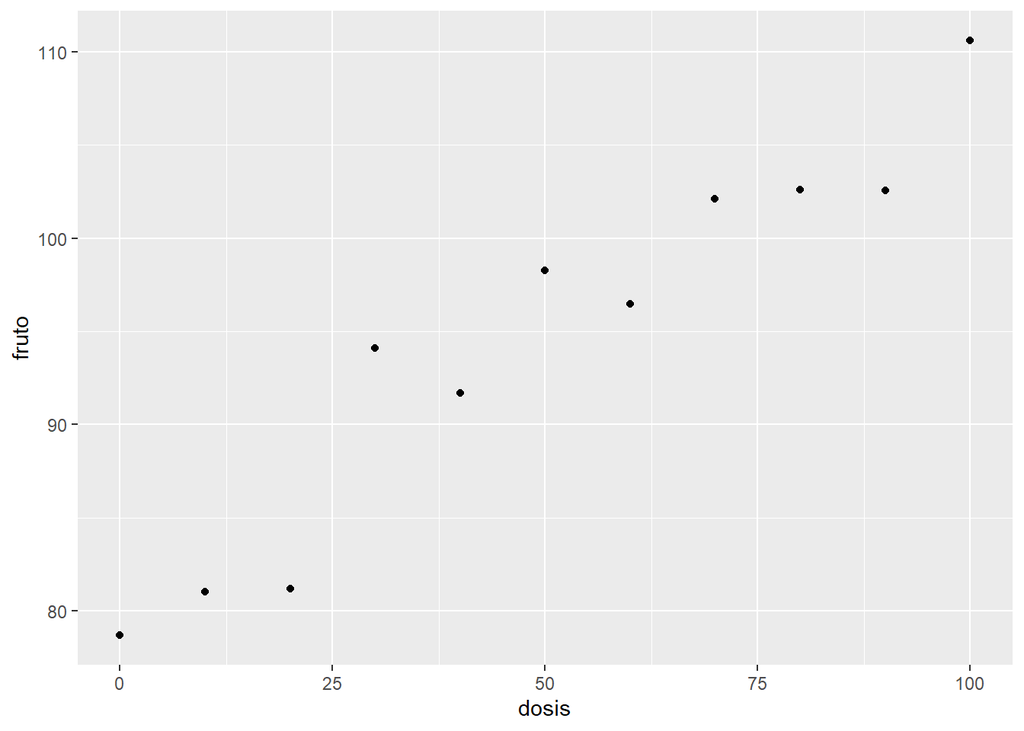

```r
library(ggplot2)
ggplot(datos, aes(x = dosis, y = fruto)) +
  geom_point()
```

Luego de ver que la nube de puntos se aproxima a una recta, trazamos una línea por el método `lm` (`lineal model`: modelo lineal en R)

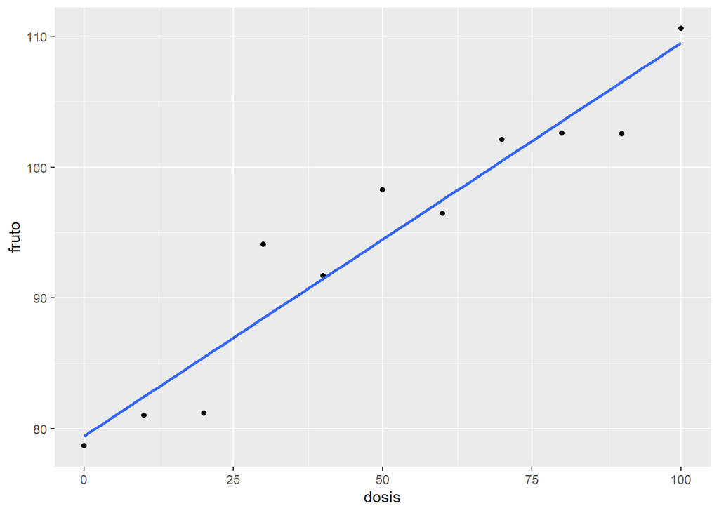

```r
ggplot(datos, aes(x = dosis, y = fruto)) +
  geom_point() +
  geom_smooth(method="lm", se = F)     # `se = F` para que no grafique un suavizado del IC
```

En las gráficas anteriores se observa que los datos pueden modelarse por un modelo de regresión lineal.

> Por más que no se solicita la realización de las gráficas, las mismas sirven de guía para orientar si la distribución de puntos se puede ajustar o no por un modelo lineal.
3. Estimaremos los parámetros de una función lineal: $Y_i = \beta_0 + \beta_1 X_i + e_i$, a través del método de mínimos cuadrados.

Ajustamos el modelo lineal, Utilizando la función `lm()`

```r
mod <- lm(fruto ~ dosis, datos)
mod
```

```
Call:
lm(formula = fruto ~ dosis, data = datos)

Coefficients:
(Intercept)        dosis
    79.4332       0.3009
```

Éstos valores:

- `(Intercept)` indica el valor de la ordenada al origen o $b_0$
- `dosis` indica el valor de la pendiente o $b_1$ (la variable “dosis” es la variable regresora)

**Respuesta:**

El modelo que mejor representa la relación entre el nivel de fertilizante utilizado y el rendimiento del fruto, es un modelo lineal:

$$Y = 79.43 + 0.3 \times X$$

Lo mismo:

$$Fruto = 79.43 + 0.3* Dosis$$

## Item (b).

**Interprete los coeficientes del modelo anterior.**

- $b_0$: es la ordenada al origen, 79.43 miles de kg/ha de fruto obtenido cuando no se aplica fertilizante (cuando “Dosis=0”),
- $b_1$: es la pendiente, o cambio marginal en la cantidad de fruto obtenido por cada unidad de fertilizante aplicado, 0.3 miles de kg/ha de fruto se obtendrán por cada unidad de dosis de fertilizante aplicado.

## Item (c).

**Pruebe las hipótesis sobre el coeficiente de regresión y redacte una conclusión completa sobre la significancia estadística del modelo ajustado. Utilice un nivel de signficancia de 0.05.**

*Coeficiente de regresión: $\beta_1$*

1. Planteo de hipótesis

$$H_0: \beta_1 = 0 \\
H_1: \beta_1 \neq 0$$

2. Estadístico de prueba y decisión a través del valor p

Alternativa 1: función `summary()`

```r
summary(mod)
```

```
Call:
lm(formula = fruto ~ dosis, data = datos)

Residuals:
    Min      1Q  Median      3Q     Max
-4.2819 -1.2260 -0.7632  1.3422  5.6487

Coefficients:
            Estimate Std. Error t value Pr(>|t|)
(Intercept)  79.4332     1.7687   44.91 6.73e-12 ***
dosis         0.3009     0.0299   10.07 3.39e-06 ***
---
Signif. codes:  0 '***' 0.001 '**' 0.01 '*' 0.05 '.' 0.1 ' ' 1

Residual standard error: 3.136 on 9 degrees of freedom
Multiple R-squared:  0.9184,    Adjusted R-squared:  0.9094
F-statistic: 101.3 on 1 and 9 DF,  p-value: 3.388e-06
```

`Residuals` es un resumen de medidas de los residuos $e_i$ (mínimo, primer cuartil, mediana, tercer cuartil y máximo)

`Coefficients`:

- `(Intercept)`: ordendada al origen o $b_0$
- `dosis`: pendiente o $b_1$
- cada una de esas líneas refresenta la inferencia sobre cada coeficiente del modelo lineal, donde:
  - `Estimate`: valor estimado de cada coeficiente
  - `Std. Error`: error estándar de cada coeficiente $S_\text{b0}$ y $S_\text{b1}$
  - `t value` estadístico de prueba de cada coeficiente (“t” calculado de cada uno)
  - `Pr(>|t|)` valor p de cada coeficiente

`Residual standard error`: error estándar residual $S_e$

`Multiple R-squared`: $R^2$, coeficiente de determinación, bondad de ajuste del modelo

`F-statistic` prueba F, sólo para significancia estadística del modelo, es decir de PH de $\beta_1$

Alternativa 2: función `anova()` o Análisis de la variancia

```r
anova(mod)
```

```
Analysis of Variance Table

Response: fruto
          Df Sum Sq Mean Sq F value    Pr(>F)
dosis      1 996.19  996.19  101.32 3.388e-06 ***
Residuals  9  88.49    9.83
---
Signif. codes:  0 '***' 0.001 '**' 0.01 '*' 0.05 '.' 0.1 ' ' 1
```

En las filas, fuentes de variación:

- `dosis`: fuente de variación de la variable regresora
- `Residuals`: fuente de variación de los resuduos

En las columnas:

- `Df`: grados de libertad de cada fuente de variación
- `Sum Sq`: Suma de cuadrados
- `Mean Sq`: Cuadrados Medios
- `F value`: estadístico de pruefa “f” (o f calculado)
- `Pr(>F)`: valor p
3. Conclusión completa
- A través de la prueba $t$, desde `summary()`

Existen evidencias suficientes para rechazar $H_0$, dado que el valor p (3.387637510^{-6}) es menor al nivel de significancia ($\alpha=0.05$), por lo tanto el coeficiente de regresión es significativo, el modelo ajustado es significativo.

- A través de la prueba $F$, desde `summary()` o desde `anova()`

Existen evidencias suficientes para rechazar $H_0$, dado que el valor p (3.387637510^{-6}) es menor al nivel de significancia ($\alpha=0.05$), por lo tanto el coeficiente de regresión es significativo, el modelo ajustado es significativo.

## Item (d).

**Interprete el IC95% y el IC99% de los parámetros relevantes.**

*La función `confint()` por defecto devuelve el 0.95.*

Intervalo de confianza del 95%

```r
confint(mod)
```

```
                 2.5 %     97.5 %
(Intercept) 75.4321053 83.4342584
dosis        0.2333058  0.3685669
```

- `(Intercept)`: hace referencia a la ordenada al origen
- `dosis`: hace referencia a la pendiene

El verdadero valor de $\beta_0$ u ordenada al origen se encuentra entre los límites inferior: 75.43 y superior: 83.43, con un nivel de confianza del 95%.

$$P(75.43 \le \beta_0 \le 83.43)=95\text{%}$$

El verdadero valor de $\beta_1$ o pendiente o cambio marginal, se encuentra entre los límites inferior: 0.233 y superior: 0.369, con un nivel de confianza del 95%.

$$P(0.233 \le \beta_1 \le 0.369)=95\text{%}$$

Intervalo de confianza del 99%

```r
confint(mod, level = 0.99)
```

```
                 0.5 %    99.5 %
(Intercept) 73.6851989 85.181165
dosis        0.2037777  0.398095
```

El verdadero valor de $\beta_0$ u ordenada al origen se encuentra entre los límites inferior: 73.69 y superior: 85.18, con un nivel de confianza del 99%.

$$P(73.69 \le \beta_0 \le 85.18)=99\text{%}$$

El verdadero valor de $\beta_1$ o pendiente o cambio marginal, se encuentra entre los límites inferior: 0.204 y superior: 0.398, con un nivel de confianza del 99%.

$$P(0.204 \le \beta_1 \le 0.398)=99\text{%}$$

## Item (e).

**Valore la bondad de ajuste del modelo.**

La bondad de ajuste del modelo la encontramos en la salida del `summary()`, como `Multiple R-squared`: 0.9184216 o expresado en porcentaje: 91.84%.

Su notación es como $R^2$ y también se lo conoce como coeficiente de determinación.

En éste caso el 91.84% de la variación del peso de los frutos de tomate es explicado por el modelo lineal planteado en función de la dosis de fertilizante. Según éste valor de $R^2$, la bondad de ajuste es muy buena.

## Item (f).

**Si se desea aplicar una dosis de fertilizante de 25 ml/ha:**

**i. Cuál es la respuesta promedio esperada de las plantas a las que se le aplique esa dosis de fertilizante con un 99% de confianza?**

Intervalo de **Confianza** de la predicción

```r
# level: por defecto es 0.95
predict(mod, newdata = list(dosis=25), interval = "confidence", level = 0.99)
```

```
       fit   lwr      upr
1 86.95659 83.04 90.87318
```

- `fit` valor ajustado o predicho
- `lwr` límite inferior
- `upr` límite superior

**ii. Que rendimiento en fruto se espera obtener con esa dosis de fertilizante?**

*Estimación puntual cuando la dosis es $X=25$ ml/ha*

Alternativa 1: reemplazando en el modelo ajustado

El modelo era: $Y = 79.43 + 0.3 \times X$

```r
x <- 25

79.4331 + 0.3009 * x
```

```
[1] 86.9556
```

Alternativa 2: utilizando la función `predict()`

```r
predict(mod, newdata = list(dosis=25))
```

```
       1
86.95659
```

De las dos maneras, obtenemos que cuando aplicamos una dosis de fertilizante de 25 ml/ha, el rendimiento de fruto de tomate esperado es de 86.96 miles de kg/ha.

**iii. Cuál es el intervalo de confianza de predicción del 99%, para la predicción anterior?**

Intervalo de **Predicción** de la predicción

```r
predict(mod, newdata = list(dosis=25), interval = "prediction", level = 0.99)
```

```
       fit      lwr      upr
1 86.95659 76.03975 97.87344
```

El intervalo de predicción del 99% para una dosis de 25 ml/ha es de $76.04;97.87$

## Item (g).

**Interprete el coeficiente que relaciona los diferentes órganos de planta evaluados.**

El coeficiente que relaciona variables es el coeficiente de correlación $r$

*En éste caso queremos evaluar la relación entre los órganos: fruto y tallo*

Alternativa 1: con la función `cor()` del paquete base de R

```r
# no importa el orden (quien pongo primero)
cor(datos$fruto, datos$tallo)
```

```
[1] 0.9553648
```

```r
# es lo mismo:
with(datos, cor(fruto, tallo))
```

```
[1] 0.9553648
```

*Signo de $r$: ver el signo de la pendiente*

`Multiple R-squared` o $R^2$: 0.9184216

```r
sqrt(0.9184216)
```

```
[1] 0.9583432
```

## Item (h).

**Pruebe la significancia estadística del coeficiente anterior. Utilice un nivel de significancia del 0.01.**

1. Planteo de hipotesis

$$H_0: \rho = 0 \\
H_1: \rho \neq 0$$

2. Estadístico de prueba y decisión a través del valor `p`

Utilizando la función `cor.test()` del paquete base de R

```r
# no importa el orden (quien pongo primero)
cor.test(datos$fruto, datos$tallo)
```

```
    Pearson's product-moment correlation

data:  datos$fruto and datos$tallo
t = 9.7015, df = 9, p-value = 4.602e-06
alternative hypothesis: true correlation is not equal to 0
95 percent confidence interval:
 0.8327229 0.9886468
sample estimates:
      cor
0.9553648
```

```r
# es lo mismo:
with(datos, cor.test(fruto, tallo))
```

```
    Pearson's product-moment correlation

data:  fruto and tallo
t = 9.7015, df = 9, p-value = 4.602e-06
alternative hypothesis: true correlation is not equal to 0
95 percent confidence interval:
 0.8327229 0.9886468
sample estimates:
      cor
0.9553648
```

Existe evidencia suficiente para rechazar la $H_0$, dado que el valor $p$ (4.610^{-6}) es menor al nivel de significancia ($\alpha=0.01$), por lo tanto la correlación es estadísticamente significativa.

El intervalo de confianza del 95%, con límites inferior 0.8327 y superior 0.9886, contienen al verdadero valor de correlación $\rho$, entre las variables fruto y tallo de tomate.

Material preparado por [Cátedra de Estadística FCA-UNL](https://github.com/estadistica-fca/)

[figure not shown]